# 01_distribuciones

Profesora Carolina Luque

**Resultado de aprendizaje:** Analiza datos de diversa índole mediante técnicas de estadística descriptiva y probabilidad.

**Hito 2:** Probabilidad.

**Temas:**

- Distribuciones de probabilidad discretas
- Distribuciones de probabilidad continuas

```python
import numpy as np
import scipy.stats as stats
import matplotlib.pyplot as plt
import math
```

# **Distribuciones de probabilidad discretas**

Se presentan algunas **distribuciones probabilísticas discretas** de uso común que son fundamentales porque representan los **modelos teóricos** de los fenómenos aleatorios frecuentes.

| Distribución | Método para $f_X(x)$ | Método para $F(x)$ |
| --- | --- | --- |
| Bernoulli | `stats.bernoulli.pmf(k, p)` | `stats.bernoulli.cdf(k, p)` |
| Binomial | `stats.binom.pmf(k, n, p)` | `stats.binom.cdf(k, n, p)` |
| Poisson | `stats.poisson.pmf(k, lambda)` | `stats.poisson.cdf(k, lambda)` |
| Geométrica | `stats.geom.pmf(k, p)` | `stats.geom.cdf(k, p)` |
| Negativa Binomial | `stats.nbinom.pmf(k, n, p)` | `stats.nbinom.cdf(k, n, p)` |
| Hipergeométrica | `stats.hypergeom.pmf(k, N, K, n)` | `stats.hypergeom.cdf(k, N, K, n)` |

## **Distribución binomial**

La **distribución de Bernoulli** es una distribución de probabilidad que consiste en la observación de un experimento aleatorio con **dos posibles resultados**.

A uno de los resultados del experimento se le denomina **"éxito"**, con probabilidad de ocurrencia $\pi$, y al otro se le llama **"fracaso"**, con probabilidad de ocurrencia $1 - \pi$, donde $\pi$ es un número real tal que $0<\pi<1$.

La **distribución binomial** está conformada por $n$ **repeticiones independientes de un experimento de Bernoulli**.

Se dice que una v.a.d. $X$ que asume valores $0,1,\ldots,n$ tiene una **distribución binomial** con parámetros $n$ y $\pi$, lo que se escribe $X\sim Bin(n,\pi)$, si la f.m.p. de $X$ está dada por:

$$ f_X(x;n,\pi) = \left\{ \begin{array}{ll} \binom{n}{x} \pi^x (1-\pi)^{n-x}, & \hbox{si $x=0,1,\ldots,n$;} \\ 0, & \hbox{en otro caso.} \end{array} \right. $$

donde $n$ es un entero positivo y $\pi$ es un número real tal que $0 < \pi <1$.

Si $n=1$, entonces la distribución binomial coincide con la **distribución Bernoulli** de parámetro $\pi$, lo que se escribe $X \sim Ber(\pi)$.

Si $X$ es una v.a. tal que $X \sim Bin(n,\pi)$, entonces:

- $\textsf{E}[X] = n\pi$.
- $\textsf{V}[X] = n\pi(1-\pi)$.

**Ejemplo** Supongamos que una empresa de comercio electrónico está lanzando una nueva campaña de marketing y quiere evaluar la probabilidad de que un número específico de clientes responda positivamente a una oferta. La empresa ha realizado un estudio previo que estima que la tasa de respuesta positiva de los clientes a la oferta es del 20%.

- ¿Cuál es la probabilidad de que exactamente 5 de 10 clientes seleccionados respondan positivamente a la oferta?
- ¿Cuál es la probabilidad de que 5 o menos clientes respondan positivamente?

```python
# parámetros de la distribución binomial
n = 10  # Número de clientes
p = 0.20  # Probabilidad de respuesta positiva
```

```python
# probabilidad de exactamente 5 respuestas positivas
k = 5
probabilidad_exacta = stats.binom.pmf(k, n, p)
print(f"Probabilidad de exactamente {k} respuestas positivas: {probabilidad_exacta:.4f}")
```

```
Probabilidad de exactamente 5 respuestas positivas: 0.0264
```

```python
# probabilidad acumulada de 5 o menos respuestas positivas
probabilidad_acumulada = stats.binom.cdf(k, n, p)
print(f"Probabilidad acumulada de 5 o menos respuestas positivas: {probabilidad_acumulada:.4f}")
```

```
Probabilidad acumulada de 5 o menos respuestas positivas: 0.9936
```

# **Distribuciones de probabilidad continuas**

| Distribución | Método para $f_X(x)$ | Método para $F(x)$ |
| --- | --- | --- |
| Normal | `stats.norm.pdf(x, mu, sigma)` | `stats.norm.cdf(x, mu, sigma)` |
| Exponencial | `stats.expon.pdf(x, scale)` | `stats.expon.cdf(x, scale)` |
| Uniforme | `stats.uniform.pdf(x, loc, scale)` | `stats.uniform.cdf(x, loc, scale)` |
| Gamma | `stats.gamma.pdf(x, a, scale)` | `stats.gamma.cdf(x, a, scale)` |
| Beta | `stats.beta.pdf(x, a, b)` | `stats.beta.cdf(x, a, b)` |
| Chi-cuadrado | `stats.chi2.pdf(x, df)` | `stats.chi2.cdf(x, df)` |
| t-Student | `stats.t.pdf(x, df)` | `stats.t.cdf(x, df)` |

## **Distribución normal**

Una de las distribuciones continuas más utilizadas es la **distribución normal** o **Gaussiana**, porque es un buen modelo para caracterizar varios **fenómenos aleatorios** en la práctica, y además, porque es fundamental para desarrollar técnicas de **inferencia estadística**.

Una v.a.c. tiene **distribución normal**, $X \sim N(\mu,\sigma^2)$, si su función de densidad de probabilidad está dada por:

$$f_X(x; \mu,\sigma^2)=\frac{1}{ \sigma\sqrt{2\pi}}\exp\left\{-\frac12\,\left(\frac{x-\mu}{\sigma}\right)^2\right\}$$

para $-\infty < x < \infty$.

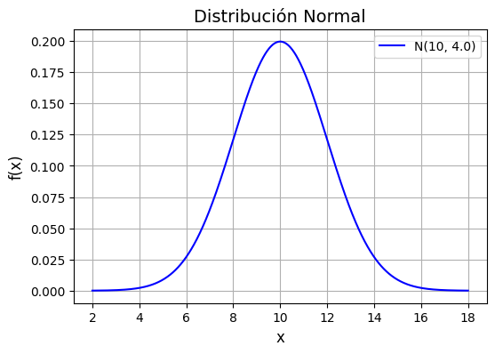

```python
from scipy.stats import norm

# parámetros de la distribución normal
mu = 10  # media
sigma = np.sqrt(4)  # desviación estándar (raíz cuadrada de la varianza)

# generar valores para la variable aleatoria
x = np.linspace(mu - 4*sigma, mu + 4*sigma, 1000)  # intervalo en el eje X (4 desviaciones estándar alrededor de la media)

# calcular la función de densidad de probabilidad (f.d.p.)
pdf = norm.pdf(x, mu, sigma)

# graficar la distribución normal
plt.figure(figsize=(6, 4))
plt.plot(x, pdf, label=f'N({mu}, {sigma**2})', color='blue')

# añadir título y etiquetas
plt.title('Distribución Normal', fontsize=14)
plt.xlabel('x', fontsize=12)
plt.ylabel('f(x)', fontsize=12)

# añadir una leyenda
plt.legend()

# mostrar el gráfico
plt.grid(True)
plt.show()
```

## **Propiedades**

Si $X \sim N(\mu,\sigma^2)$ y $Y = aX+b$ con $a$ y $b$ constantes, entonces:

- $\textsf{E}[X] = \mu$.
- $\textsf{V}[X] = \sigma^2$.
- Es simétrica alrededor de $\mu$
- $Y\sim N(a\mu+b,a^2\sigma^2)$

## **Regla empírica**

Si $X \sim N(\mu,\sigma^2)$, entonces:

- $P(\mu-1\sigma< X <\mu+1\sigma)=0.6827$
- $P(\mu-2\sigma< X <\mu+2\sigma)=0.9545$
- $P(\mu-3\sigma< X <\mu+3\sigma)=0.9973$

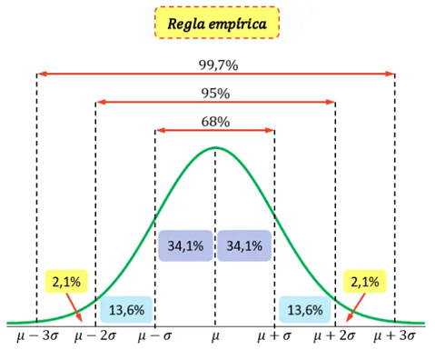

**Ejemplo: cálculo de probabilidades distribución normal**

El jefe del departamento de riesgos de una institución financiera afirma que la distribución de los puntajes de crédito de los solicitantes sigue una distribución normal con una media de 650 y una desviación estándar de 50. Este modelo probabilístico es útil para analizar el comportamiento de los puntajes de crédito de los solicitantes de préstamos.

- ¿Cuál es la probabilidad de que un solicitante tenga un puntaje de crédito inferior a 700?
- ¿Cuál es la probabilidad de que un solicitante tenga un puntaje de crédito entre 600 y 700?
- Si se reciben 200 solicitudes y solo aquellos con puntaje superior a 750 tendrán aprobación ¿cuántos créditos se espera sean aprobados?

```python
# Parámetros
mu = 650  # Media de puntajes de crédito
sigma = 50  # Desviación estándar de puntajes de crédito
```

```python
# Puntajes a evaluar
puntaje_superior = 700
puntaje_inferior = 600
```

```python
# Calcular la probabilidad de que el puntaje sea superior a 700
probabilidad_superior = stats.norm.cdf(puntaje_superior, mu, sigma)
print(f'La probabilidad de que un solicitante tenga un puntaje de crédito superior a {puntaje_superior} es: {probabilidad_superior:.4f}')
```

[output not shown]

```python
# Calcular la probabilidad de que el puntaje esté entre 600 y 700
probabilidad_entre = stats.norm.cdf(puntaje_superior, mu, sigma) - stats.norm.cdf(puntaje_inferior, mu, sigma)
print(f'La probabilidad de que un solicitante tenga un puntaje de crédito entre {puntaje_inferior} y {puntaje_superior} es: {probabilidad_entre:.4f}')
```

```
La probabilidad de que un solicitante tenga un puntaje de crédito entre 600 y 700 es: 0.6827
```

```python
puntaje_superior = 750
numero_solicitudes = 200

# calcular la probabilidad de que el puntaje sea superior a 750
probabilidad_superior = 1 - stats.norm.cdf(puntaje_superior, mu, sigma)

# calcular el número esperado de aprobaciones
numero_esperado_aprobaciones = probabilidad_superior * numero_solicitudes

# redondear al entero más cercano por debajo
numero_esperado_aprobaciones_redondeado = math.floor(numero_esperado_aprobaciones)

print(f'Número esperado de créditos aprobados (redondeado hacia abajo): {numero_esperado_aprobaciones_redondeado}')
```

```
Número esperado de créditos aprobados (redondeado hacia abajo): 4
```

**Ejemplo: cálculo de percentiles distribución normal**

Una empresa de tecnología ha recopilado datos sobre los tiempos de carga de su página web principal. Según las estadísticas, los tiempos de carga siguen una distribución normal con una media de 8 segundos y una desviación estándar de 2 segundos.

- ¿Qué tiempo de carga delimita al 90% de los tiempos?
- ¿Qué tiempo de carga delimita al 25% de los tiempos?
- Si se considera que los tiempos de carga superiores al percentil 95 son inaceptables para los usuarios, ¿cuál es el tiempo de carga por encima del cual se consideraría que la experiencia del usuario es deficiente?

```python
# parámetros de la distribución normal
mu = 8  # media (segundos)
sigma = 2  # desviación estándar (segundos)

# percentiles que queremos calcular
percentil_90 = norm.ppf(0.90, mu, sigma)
percentil_25 = norm.ppf(0.25, mu, sigma)
percentil_95 = norm.ppf(0.95, mu, sigma)

print(f"El percentil 90 es: {percentil_90:.2f} segundos")
print(f"El percentil 25 es: {percentil_25:.2f} segundos")
print(f"El percentil 95 es: {percentil_95:.2f} segundos")
```

```
El percentil 90 es: 10.56 segundos
El percentil 25 es: 6.65 segundos
El percentil 95 es: 11.29 segundos
```

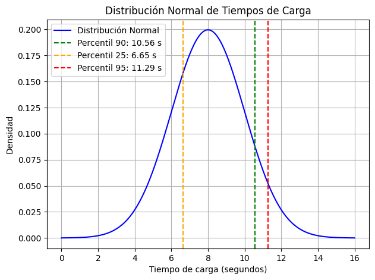

```python
# Graficar la distribución normal y marcar los percentiles
x = np.linspace(mu - 4*sigma, mu + 4*sigma, 1000)
pdf = norm.pdf(x, mu, sigma)

plt.figure(figsize=(7, 5))
plt.plot(x, pdf, label='Distribución Normal', color='blue')

# Marcar los percentiles en el gráfico
plt.axvline(x=percentil_90, color='green', linestyle='--', label=f'Percentil 90: {percentil_90:.2f} s')
plt.axvline(x=percentil_25, color='orange', linestyle='--', label=f'Percentil 25: {percentil_25:.2f} s')
plt.axvline(x=percentil_95, color='red', linestyle='--', label=f'Percentil 95: {percentil_95:.2f} s')

# Añadir títulos y etiquetas
plt.title('Distribución Normal de Tiempos de Carga')
plt.xlabel('Tiempo de carga (segundos)')
plt.ylabel('Densidad')
plt.legend()

# Mostrar el gráfico
plt.grid(True)
plt.show()
```

# **Referencias**

- Rajagopalan, G. (2021). A Python Data Analyst's Toolkit: Learn Python and Python-based Libraries with Applications in Data Analysis and Statistics. Springer.
- Igual, L. and Seguí, S. (2017). Introduction to Data Science A Python Approach to Concepts, Techniques and Applications. Springer.
- Haslwanter, T. (2016). An Introduction to Statistics with Python With Applications in the Life Sciences. Springer.